## Homework 7

#### Due Friday, March 19, 11:59 PM CT

Problems 1 - 6 use the exoplanet data set to practice using string and regular expression commands, and the remaining are probability questions. Recall that the data were pulled from the [NASA Exoplanet Archive](https://exoplanetarchive.ipac.caltech.edu/index.html) on September 3, 2020.

Note that several of the questions are optional and will not be graded. (We will post solutions for all problems listed.)

The following block of code will read in the exoplanet data from the file *exoplanets-3sept2020.csv*, filter to include only confirmed exoplanets, select and rename a subset of variables, and add an index with the row number.

```r
planets <- read_csv("../../data/exoplanets-3sept2020.csv")%>%
  filter(default_flag == 1) %>%
  select(pl_name, hostname, discoverymethod, disc_year, disc_facility,
         sy_pnum, pl_rade, pl_bmasse, rowupdate) %>%
  rename(planet=pl_name, star=hostname, method=discoverymethod,
         facility=disc_facility, year=disc_year, number=sy_pnum,
         radius=pl_rade, mass=pl_bmasse, update=rowupdate) %>%
  mutate(index = row_number()) %>%
  select(index, everything())
```

### 1

Create and print a table which shows the number of exoplanets discovered that have the word “Kepler” as part of the planet name, grouped by `year` and `facility`.

What year was the first of these exoplanets discovered by a facility *other than* the Kepler facility?

- 2013

```r
planets %>%
  filter(str_detect(planet, "Kepler")) %>%
  group_by(facility, year) %>%
  summarise(count = n())
```

```
## # A tibble: 22 x 3
## # Groups:   facility [8]
##    facility                           year count
##    <chr>                             <dbl> <int>
##  1 Fred Lawrence Whipple Observatory  2015     1
##  2 Kepler                             2009     4
##  3 Kepler                             2010    11
##  4 Kepler                             2011    51
##  5 Kepler                             2012    58
##  6 Kepler                             2013    58
##  7 Kepler                             2014   777
##  8 Kepler                             2015    38
##  9 Kepler                             2016  1286
## 10 Kepler                             2017     9
## # ... with 12 more rows
```

### 2

The column `update` in the exoplanet data set has character values where some entries have a date only, such as `5/14/14` and others have a date and time, such as `9/4/18 16:14`.

Create a new column named `update_format` with the value “date” if the format is like `5/14/14`, “datetime” if the format is like `9/4/18 16:14`, and “other” if it is something else.

Print out a summary table that counts the number of observations have each type of `update_formate`.

```r
planets<-planets %>%
  mutate(update_format = case_when(str_detect(update, " ") ~ "datetime", !str_detect(update, " ") ~ "date",TRUE~"other"))
planets%>%
  group_by(update_format) %>%
  summarise(count = n())
```

```
## # A tibble: 2 x 2
##   update_format count
## * <chr>         <int>
## 1 date           1376
## 2 datetime       2900
```

### 3

How many *distinct* star names begin with a number?

```r
df2<-planets%>%
  select(star)%>%
  filter(str_detect(star,"^\\d"))%>%
  distinct()%>%
  summarize(n=n())

df2
```

```
## # A tibble: 1 x 1
##       n
##   <int>
## 1    32
```

### 4 (Optional, ungraded)

Of the distinct star names that begin with a number, create a bar plot of these leading numbers. The height of the bars should indicate the number of stars for each leading number.

- Display the bars in numerical order (lowest number to the left of the plot window), and include a tick mark and label (indicating the leading number) for each bar.
- Be sure to include descriptive axis labels and a title.

*Hint: First create a variable with the leading number from the star names, then create the bar plot. Be careful because some numbers have more than one digit.*

- What are the name of the stars that have the most common leading number? Print out a table with these star names.

### 5 (Optional, ungraded)

The convention for naming planets is typically to take the name of the star and then add a lower-case letter (e.g., b, c) following the star name. However, not all planet names follow this convention.

How many planet names do not follow this convention?

Note: special care is required if the name of the star contains a symbol with special meaning in a regular expression, such as `+`.

*Hint: You may find it helpful to create a column with the regular expression you wish to compare to the planet name.*

### 6

Find all the planets where the planet name is the name of the star, a space, and then something else we will label a suffix. For example, the planet “11 Com b” is orbiting the star “11 Com” - the suffix would be the “b”. Create a data frame where you add a variable named `suffix` which contains this suffix.

1. Create and print out a summary table that counts the number of times each single lower case letter is used, arranged from most to least frequent use. This table should only include suffixes that are a single lower-case letter.
2. In how many cases is the suffix a single lower case letter?
- There are 4246 cases is the suffix a single lower case letter.

```r
suffix_df <- planets %>%
  filter(str_sub(planet, 1, str_length(star) + 1) == str_c(star, " ")) %>%
  mutate(suffix = str_sub(planet, str_length(star) + 2, str_length(planet)))

suffix_df %>%
  filter(str_detect(suffix, "^[:lower:]$")) %>%
  group_by(suffix) %>%
  summarise(count = n()) %>%
  arrange(desc(count))
```

```
## # A tibble: 7 x 2
##   suffix count
##   <chr>  <int>
## 1 b       3161
## 2 c        710
## 3 d        239
## 4 e         89
## 5 f         31
## 6 g         11
## 7 h          5
```

## Probability Problems

A discrete random variable $X$ has possible values and probabilities contained in the following data frame which includes some missing values.

Use this distribution for the following four problems.

```r
pmf_df <- tibble(
  x = c(-5, -2, 0, 1, 3),
  p = c(0.1, 0.25, .15, NA, 0.2)
)
pmf_df
```

```
## # A tibble: 5 x 2
##       x     p
##   <dbl> <dbl>
## 1    -5  0.1
## 2    -2  0.25
## 3     0  0.15
## 4     1 NA
## 5     3  0.2
```

### 7

What is $P(X = 1)$? Briefly explain how you arrived at the answer.

- P(X = 1) = 1 - P(X = -5) - P(X = -2) - P(X = 0) - P(X = 3) = 1 - 0.1 - 0.25 - 0.15-0.2 = 0.3

### 8

What are the expected value (mean) and variance of the distribution of $X$?

```r
prob8 <- replace_na(pmf_df, list(p = 0.3))
# expected value (mean)
mean = sum(prob8[["x"]] * prob8[["p"]])
# variance of the distribution
variance = sum((prob8[["x"]] - mean)^2 * prob8[["p"]])
mean
```

```
## [1] -0.1
```

```r
variance
```

```
## [1] 5.59
```

### 9

Create a graph which has a line segment from y = 0 to the probability for each possible value of $X$ to visualize its probability mass function. Since there are 5 possible values for $X$, you should have 5 vertical bars on your graph.

Hint: consider using the **ggplot2** command `geom_segment()`.

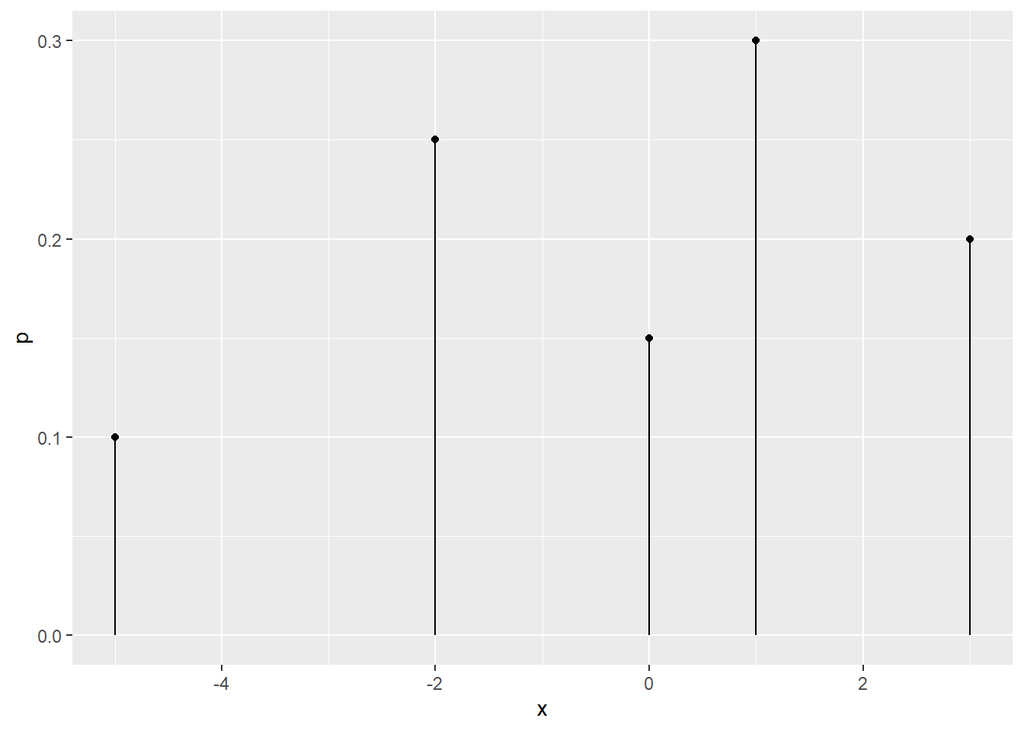

```r
ggplot(prob8, mapping = aes(x = x, y = p)) +
  geom_point() +
  geom_segment(mapping = aes(xend = x, yend = 0))
```

### 10 (Optional, ungraded)

Add a column named `cdf` (representing the “cumulative distribution function” of X) to the `pmf_df` table which contains the value $P(X \le x)$ for each case. Use the function `geom_step()` to graph this function. *Hint: the base R function `cumsum()` which calculates a cumulative sum may be helpful.*

The graph of the function will look better if you also include $x$ values below -5 and above 3 (e.g., -6 and 4). You can assign these new values probabilities of 0 and bind them to the `pmf_df` table.

You graphic should look like a step-function that starts at zero on the left and increases to 1 on the right.